# HW2

Lowson Li, R08323023

# 1 Strategy

1. Try to replicate the [YTM calculator](https://www.calkoo.com/en/ytm-calculator)
2. Try to replicate the spot rate examples from [綠角](http://greenhornfinancefootnote.blogspot.com/2010/06/how-to-compute-theoretical-spot-rates.html) and [simple spot rate](https://www.trignosource.com/finance/spot%20rate.html#Calculator)
3. Practice for other simple calculators.

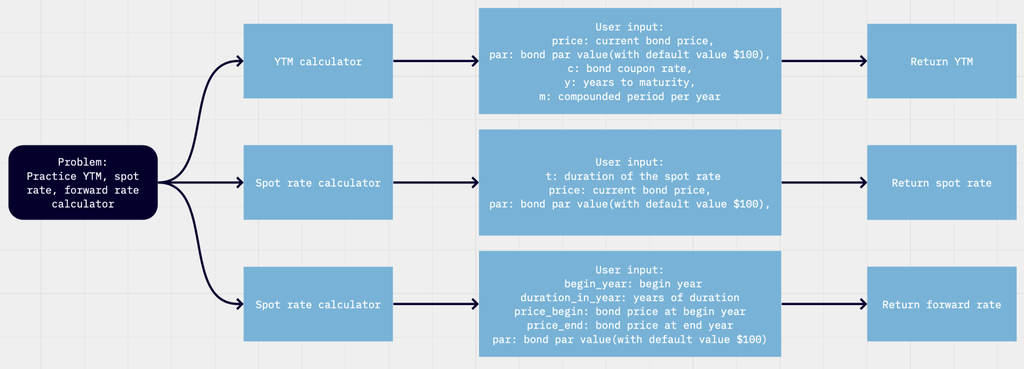

- For more details of the code and instructions, please visit my [Github](https://github.com/isthatlowsonli/Financial_Engineering)
- [Source code](https://github.com/isthatlowsonli/Financial_Engineering/blob/master/Script/HW2.Rmd)
- [Academic Portfolio](https://isthatlowsonli.github.io//Financial_Engineering/Script/practice.nb.html)

# 2 Load packages

```r
library(dplyr)
library(knitr)
library(kableExtra)
```

# 3 YTM calculator

- Use the data from [Bloomberg](https://www.bloomberg.com/markets/rates-bonds/government-bonds/us)

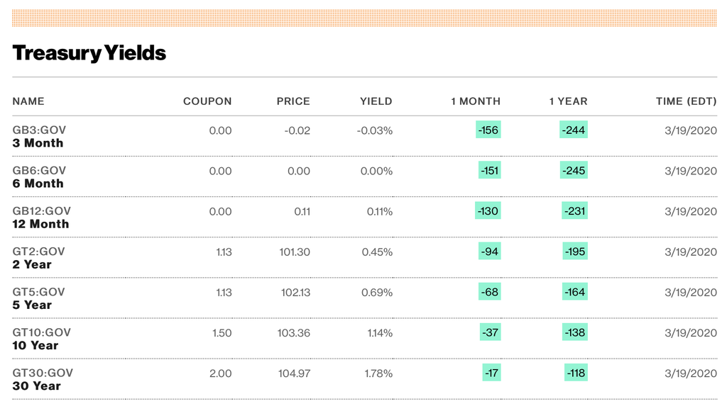

## 3.1 Define function

```r
# define function
ytm <- function(price, par = 100, c, y, m) { # price:current bond price, par: bond par value(with default value $100), c: bond coupon rate, y: years to maturity, m: compounded period per year
  cash_flow <<- c(rep(par * c / m, y * m - 1), par * c / m + par) # create cash flow vector
  objective_fn <<- function(r, cash_flow, t = seq(along = cash_flow)) sum(-price,cash_flow / (1 + r)^t) # setting the objective function to find the YTM, represented as 'r'
  ytm_ans <<- uniroot(f = objective_fn, interval = c(0, 1), cash_flow = cash_flow)$root # find the root of the objective function
  return(paste(round(ytm_ans, 5) * 100, "%"))
}
```

```r
# clean version
ytm <- function(price, par = 100, c, y, m) {
  cash_flow <<- c(rep(par * c / m, y * m - 1), par * c / m + par)
  objective_fn <<- function(r, cash_flow, t = seq(along = cash_flow)) sum(-price, cash_flow / (1 + r)^t)
  ytm_ans <<- uniroot(f = objective_fn, interval = c(0, 1), cash_flow = cash_flow)$root
  return(paste(round(ytm_ans, 5) * 100, "%"))
}
```

## 3.2 Results

- For bonds with 10 years to maturity (with Bloomberg data):

```r
ytm(price = 103.36, c = 0.015, y = 10, m = 1)
```

```
[1] "1.142 %"
```

- Note: you can check the result by [online YTM calculator](https://www.calkoo.com/en/ytm-calculator)

# 4 Spot rate calculator

## 4.1 綠角 example

### 4.1.1 Define function

- Assume compound semiannually
- Try to find spot rate with YTM of zero-coupon bonds: 6 month & 12 month

```r
# define function
spot_rate <- function(price, par = 100, c, m, six_mo_ytm, twelve_mo_ytm) {
  cash_flow <<- c(rep(par * c / m, 2), par + par * c / m)
  objective_fn <<- function(s, cash_flow, t = seq(from = 1, along = cash_flow)) sum(-price, cash_flow / (1 + c(six_mo_ytm / m, twelve_mo_ytm / m, s))^t)
  spot_ans <<- uniroot(f = objective_fn, interval = c(0, 1), cash_flow = cash_flow)$root
  return(paste(round(spot_ans * 2, 5) * 100, "%"))
}
```

### 4.1.2 Results

- Calculate the spot rate per annum (with example from [綠角](http://greenhornfinancefootnote.blogspot.com/2010/06/how-to-compute-theoretical-spot-rates.html))

```r
# result
spot_rate_g(price = 1029.1, par = 1000, c = 0.05, m = 2, y = 1.5, ytms =c(0.01, 0.02))
```

[output not shown]

- For a level-coupon bond with price 1029.1, par value 1000, annual coupon rate 5%, compound twice per year and 1.5 year to maturity. Along with the spot rate for 6 months bond and 12 months bond 1% and 2% seperately, we have the equivelent spot rate 3.029 %.
- If the spot rates of the zero-coupon bonds are **not enough** to calculate the spot rate of the given level-coupon bonds: new spot rates are generate from previous ones, this is called **boostraping**

## 4.2 Simple case

- This is the simplified case for calculating the spot rate of the zero-coupon bond.
- Methodology and examples [here](https://www.trignosource.com/finance/spot%20rate.html#Calculator)

### 4.2.1 Define function

```r
# define function
simple_spot_rate <- function(t, price, par = 100) {
  sp <<- (price/par)^(-1 / t) -1
  sf <<- log(1 + sp)
  sp_return <<- paste(t, "year spot rate of interest", round(sp * 100, 2), "%")
  sf_return <<- paste(t, "year spot force of interest", round(sf * 100, 2), "%")
  return(cat(sp_return, sf_return, sep = "\n"))
}
```

### 4.2.2 Results

```r
# result, with numbers from the website demo
simple_spot_rate(t = 4, price = 68.30)
```

```
4 year spot rate of interest 10 %
4 year spot force of interest 9.53 %
```

# 5 Forward rate calculator

## 5.1 Simple case

- This is the simplified case for calculating the forward rate of the zero-coupon bond.
- Methodology and examples [here](https://www.trignosource.com/finance/Forward%20rate.html#Calculator)

### 5.1.1 Define function

```r
forward_rate <- function(begin_year, duration_in_year, price_begin, price_end, par = 100) {
  pb <<- price_begin / par
  pe <<- price_end / par
  fr <<- (pb / pe)^(1 / duration_in_year) - 1
  ff <<- log(pb / pe) / duration_in_year
  fr_return <<- paste(duration_in_year, "year forward rate of interest begining", begin_year, "years from now:", round(sp * 100, 2), "%")
  ff_return <<- paste(duration_in_year, "year forward force of interest begining", begin_year, "years from now:", round(sf * 100, 2), "%")
  return(cat(fr_return, ff_return, sep = "\n"))
}
```

### 5.1.2 Results

```r
forward_rate(begin_year = 3,duration_in_year = 2,price_begin = 83,price_end = 67.43)
```

```
2 year forward rate of interest begining 3 years from now: 10 %
2 year forward force of interest begining 3 years from now: 9.53 %
```

## 5.2 Save in matrix form

### 5.2.1 Define function

```r
# create and save forward rates in matrix
forward_rates <- function(price_begin, price_end, periods = 5, par = 100) {
  frs <<- c()
  for (i in 0:periods) {
    for (j in 0:periods) {
      if (j > i) {
        pb <<- price_begin / par
        pe <<- price_end / par
        fr <<- (pb / pe)^(1 / j - i) - 1
        frs <<- c(frs,fr)
      } else {
        frs <<- c(frs,0)
      }
    }
  }
  mat<<-matrix(data = frs, nrow = periods+1, ncol =periods+1) %>% t()
  return(mat)
}
```

### 5.2.2 Results

```r
forward_rates(price_begin = 83, price_end = 67.43)
```

```
     [,1]      [,2]        [,3]        [,4]        [,5]
[1,]    0 0.2309061  0.10946209  0.07170431  0.05331006
[2,]    0 0.0000000 -0.09866231 -0.12933709 -0.14428075
[3,]    0 0.0000000  0.00000000 -0.29266506 -0.30480544
[4,]    0 0.0000000  0.00000000  0.00000000 -0.43521724
[5,]    0 0.0000000  0.00000000  0.00000000  0.00000000
[6,]    0 0.0000000  0.00000000  0.00000000  0.00000000
           [,6]
[1,]  0.0424254
[2,] -0.1531236
[3,] -0.3119894
[4,] -0.4410536
[5,] -0.5459065
[6,]  0.0000000
```

- Note that the value in $(1,1)$ means $f(0,0)$, $(1,2)$ means $f(0,1)$
- `R` follows mathematic tradition to index the value.

# 6 Practice

- Calculate bond price and YTM from spot rate

```r
# bond price calculator (from spot rates)
bp <- function(par, c, spot_rates) {
  bond_price <<- sum(par * c(rep(c, length(spot_rates) - 1), 1 + c) / (1 + spot_rates)^seq(along = spot_rates))
  return(bond_price)
}
```

```r
# results
bp(par = 1000, c = 0.09, spot_rates = c(0.06, 0.12, 0.13))
```

```
[1] 912.0778
```

- Since we can calculate the bond price under given spot rates, we can also derive YTM:

```r
# results
ytm(price = bond_price, par = 1000, c = 0.09, y = 3, m = 1)
```

```
[1] "12.705 %"
```

# 7 Reference

[YTM code practice from DataCamp](https://campus.datacamp.com/courses/bond-valuation-and-analysis-in-r/yield-to-maturity?ex=12)

[`uniroot` function documentation](https://www.rdocumentation.org/packages/stats/versions/3.6.2/topics/uniroot)